# Portofolio 5: Final Project: Tracing the Enlightenment Thought in the Encyclopédie

Kristian Jensby

created on 20 May 2026 and updated 21 May, 2026

### Loading packages

```r
library(tidyverse)
library(here)
library(pdftools)
```

```r
library(tidytext)
library(textdata)
library(ggwordcloud)
```

### Importing the Encyclopedia text by D’Alembert and Diderot:

```r
Encyclopedia_path <- here("data","Diderot_Encyclopedia.pdf")
Encyclopedia_text <- pdf_text(Encyclopedia_path)
```

### In order do to a sentiment analysis I of the Encyclopedia I need to structurise the text by doing some wrangling:

- Split up pages into separate lines (separated by `\n`) using `stringr::str_split()`
- Unnesting into regular columns using `tidyr::unnest()`
- Removing leading/trailing white space with `stringr::str_trim()`

```r
Encyclopedia_df <- data.frame(Encyclopedia_text) %>%
  mutate(text_full = str_split(Encyclopedia_text, pattern = '\n')) %>%
  unnest(text_full) %>%
  mutate(text_full = str_trim(text_full))
```

Now each line, on each page, is its own row, with extra starting & trailing spaces removed.

### Getting the tokens (individual words) in tidy format

I am using `tidytext::unnest_tokens()` (which is pulling from the `tokenizer`) package, to split columns into tokens. I am interested in *words*, so that’s the token I’ll use:

```r
Encyclopedia_tokens <- Encyclopedia_df %>%
  unnest_tokens(word, text_full)

# Now each word has its own row
```

Counting the words

```r
Encyclopedia_wc <- Encyclopedia_tokens %>%
  count(word) %>%
  arrange(-n)
Encyclopedia_wc
```

```
## # A tibble: 18,178 × 2
##    word      n
##    <chr> <int>
##  1 the   20469
##  2 of    12840
##  3 and    8665
##  4 to     8245
##  5 in     6460
##  6 that   4774
##  7 a      4446
##  8 is     4092
##  9 it     3262
## 10 for    2458
## # ℹ 18,168 more rows
```

Now I am noticing that a lot of words show up frequently that I am not so interested in for this analysis (e.g. “the”, “of”, “and”, etc.). These are *stop words* and now I will remove them.

### Removing stop words:

I use `?stop_words` and `View(stop_words)`to look at documentation for stop words lexicons.

I will *remove* stop words using `tidyr::anti_join()`:

```r
Encyclopedia_stop <- Encyclopedia_tokens %>%
  anti_join(stop_words) %>%
  select(-Encyclopedia_text)
```

Now I check the counts again:

```r
Encyclopedia_swc <- Encyclopedia_stop %>%
  count(word) %>%
  arrange(-n)
```

### Creating a wordcloud of Encyclopedia report words for a thematic overview

```r
# Filtering words into the most 80 frequent as the wordcloud as it is a simple thematic overview
Encyclopedia_top80 <- Encyclopedia_stop %>%
  count(word) %>%
  arrange(-n) %>%
  head(80)
Encyclopedia_top80
```

```
## # A tibble: 80 × 2
##    word           n
##    <chr>      <int>
##  1 laws         932
##  2 people       708
##  3 law          649
##  4 de           647
##  5 government   625
##  6 power        469
##  7 nature       415
##  8 public       406
##  9 liberty      405
## 10 political    380
## # ℹ 70 more rows
```

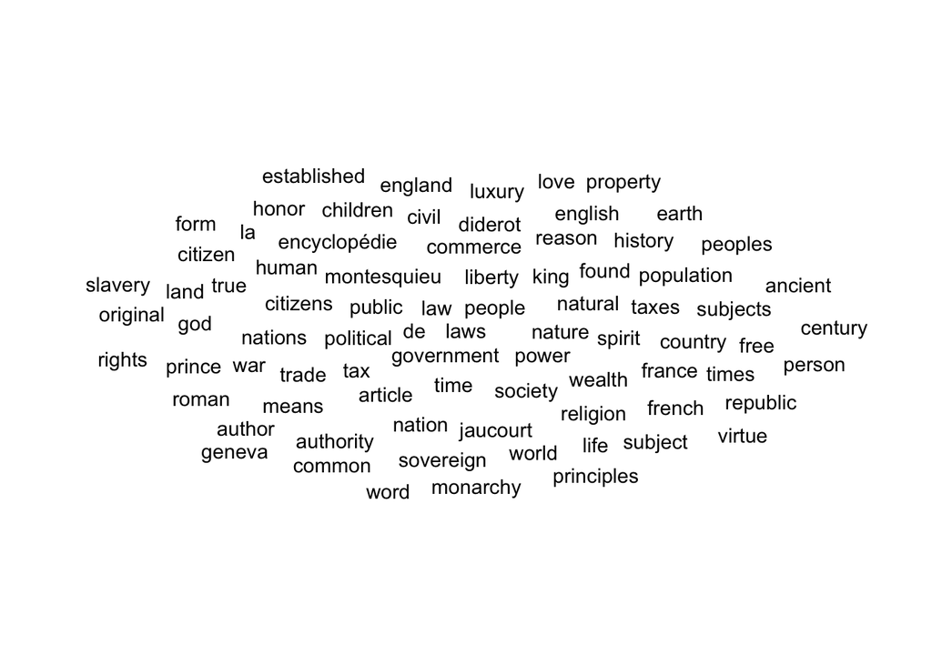

```r
Encyclopedia_cloud <- ggplot(data = Encyclopedia_top80, aes(label = word)) +
  geom_text_wordcloud() +
  theme_minimal()

Encyclopedia_cloud
```

Now I am customising it a bit for the sake of the visualisation:

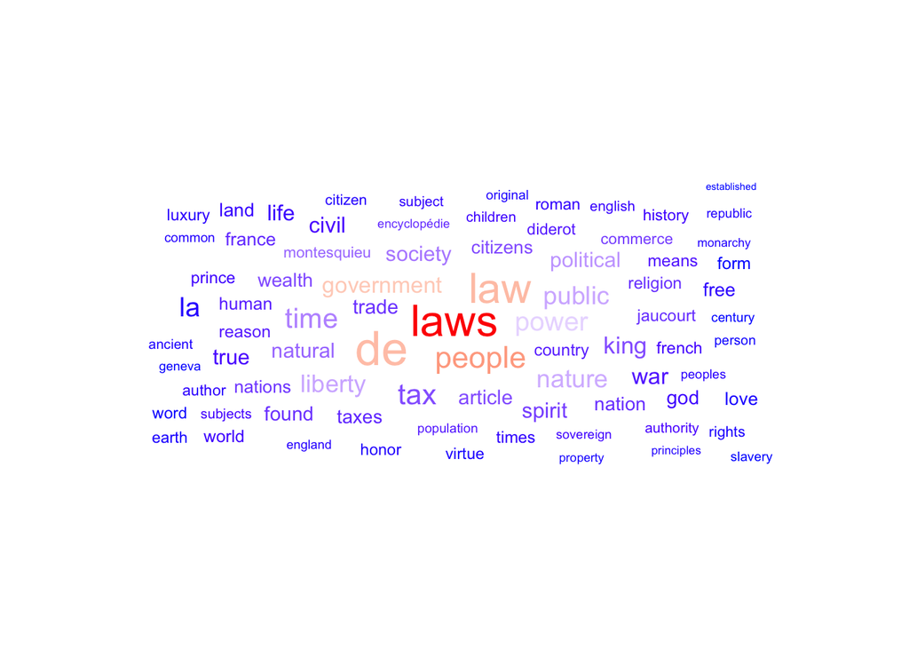

```r
ggplot(data = Encyclopedia_top80, aes(label = word, size = n)) +
  geom_text_wordcloud_area(aes(color = n), shape = "square") +
  scale_size_area(max_size = 16) +
  scale_color_gradientn(colors = c("blue","white","red")) +
  theme_minimal()
```

### Sentiment analysis

```r
# Downloading the afiin lexicon
get_sentiments(lexicon = "afinn")
```

```
## # A tibble: 2,477 × 2
##    word       value
##    <chr>      <dbl>
##  1 abandon       -2
##  2 abandoned     -2
##  3 abandons      -2
##  4 abducted      -2
##  5 abduction     -2
##  6 abductions    -2
##  7 abhor         -3
##  8 abhorred      -3
##  9 abhorrent     -3
## 10 abhors        -3
## # ℹ 2,467 more rows
```

```r
#Downloading the nrc lexicon
get_sentiments(lexicon = "nrc")
```

```
## # A tibble: 13,872 × 2
##    word        sentiment
##    <chr>       <chr>
##  1 abacus      trust
##  2 abandon     fear
##  3 abandon     negative
##  4 abandon     sadness
##  5 abandoned   anger
##  6 abandoned   fear
##  7 abandoned   negative
##  8 abandoned   sadness
##  9 abandonment anger
## 10 abandonment fear
## # ℹ 13,862 more rows
```

Now I am doing sentiment analysis on the Encyclopedia text data using afinn and nrc.

### Sentiment analysis with afinn:

First, I bind words in `Encyclopedia_stop` to `afinn` lexicon:

```r
Encyclopedia_afinn <- Encyclopedia_stop %>%
  inner_join(get_sentiments("afinn"))
Encyclopedia_afinn
```

```
## # A tibble: 11,779 × 2
##    word        value
##    <chr>       <dbl>
##  1 encourage       2
##  2 free            1
##  3 responsible     2
##  4 freedom         2
##  5 united          1
##  6 authority       1
##  7 masterpiece     4
##  8 natural         1
##  9 natural         1
## 10 natural         1
## # ℹ 11,769 more rows
```

Finding some counts (by sentiment ranking):

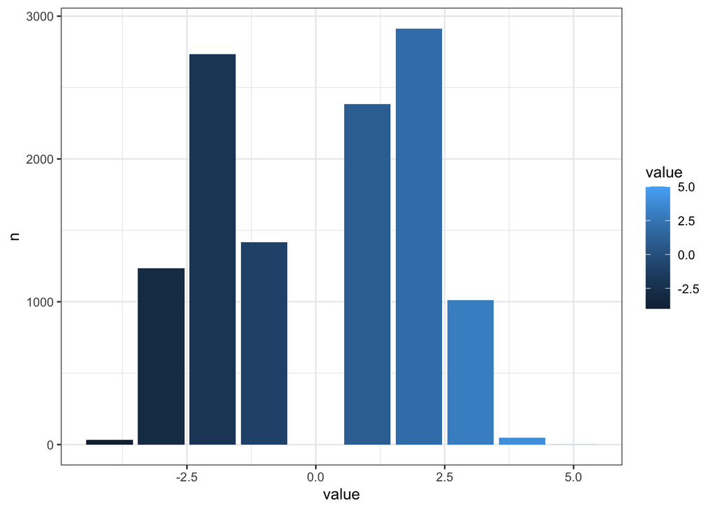

```r
Encyclopedia_afinn_hist <- Encyclopedia_afinn %>%
  count(value)

# Plotting them:
ggplot(data = Encyclopedia_afinn_hist, aes(x = value, y = n)) +
  geom_col(aes(fill = value)) +
  theme_bw()
```

Summarisiing sentiment for the text:

```r
Encyclopedia_summary <- Encyclopedia_afinn %>%
  summarize(
    mean_score = mean(value),
    median_score = median(value)
  )
Encyclopedia_summary
```

```
## # A tibble: 1 × 2
##   mean_score median_score
##        <dbl>        <dbl>
## 1     0.0608            1
```

The mean and median indicate a slightly positive overall sentiments based on the AFINN lexicon.

### NRC lexicon for sentiment analysis

As above, I’ll use inner_join() to combine the Encyclopedia non-stopword text with the nrc lexicon:

```r
Encyclopedia_nrc <- Encyclopedia_stop %>%
  inner_join(get_sentiments("nrc"))
```

Then I check which words are being excluded by using `anti_join()`:

```r
Encyclopedia_exclude <- Encyclopedia_stop %>%
  anti_join(get_sentiments("nrc"))
# View(Encyclopedia_exclude)

# Counting to find the most excluded:
Encyclopedia_exclude_n <- Encyclopedia_exclude %>%
  count(word, sort = TRUE)

head(Encyclopedia_exclude_n)
```

```
## # A tibble: 6 × 2
##   word          n
##   <chr>     <int>
## 1 laws        932
## 2 people      708
## 3 de          647
## 4 power       469
## 5 nature      415
## 6 political   380
```

Now I find some counts:

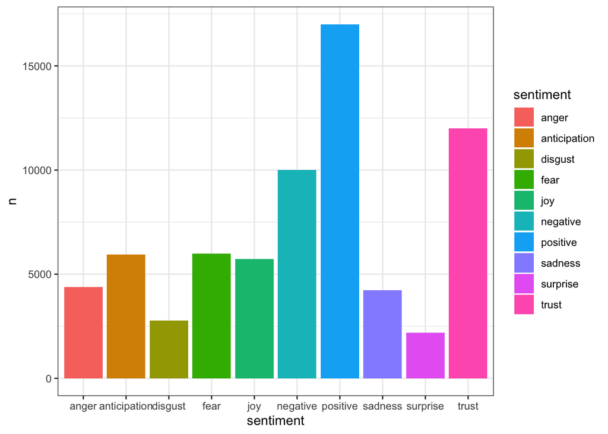

```r
Encyclopedia_nrc_n <- Encyclopedia_nrc %>%
  count(sentiment, sort = TRUE)

# And I plot them:

ggplot(data = Encyclopedia_nrc_n, aes(x = sentiment, y = n)) +
  geom_col(aes(fill = sentiment))+
  theme_bw()
```

Or I can count by sentiment and word, then facet:

```r
Encyclopedia_nrc_n5 <- Encyclopedia_nrc %>%
  count(word,sentiment, sort = TRUE) %>%
  group_by(sentiment) %>%
  top_n(5) %>%
  ungroup()
```

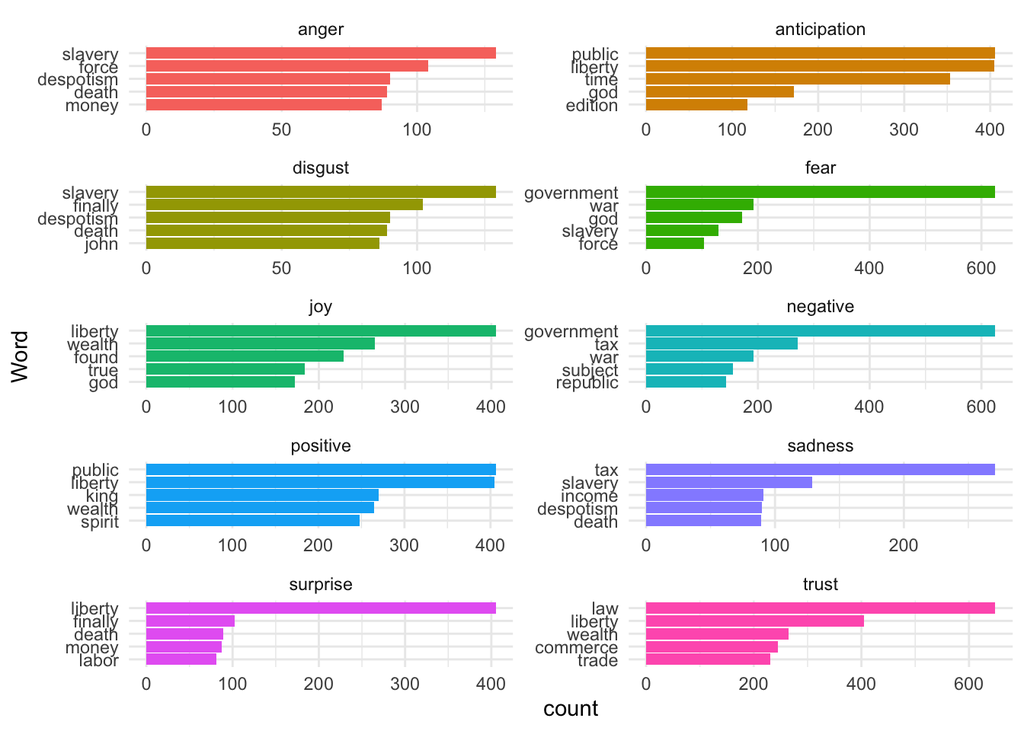

```r
Encyclopedia_nrc_gg <- ggplot(data = Encyclopedia_nrc_n5, aes(x = reorder(word,n), y = n, fill = sentiment)) +
  geom_col(show.legend = FALSE) +
  facet_wrap(~sentiment, ncol = 2, scales = "free") +
  coord_flip() +
  theme_minimal() +
  labs(x = "Word", y = "count")

# Showing it
Encyclopedia_nrc_gg
```

```r
# Saving it
ggsave(plot = Encyclopedia_nrc_gg,
       here("figures","Encyclopedia_nrc_sentiment.png"),
       height = 12,
       width = 7)
        labs(x = "Word", y = "count")
```

```
## <ggplot2::labels> List of 2
##  $ x: chr "Word"
##  $ y: chr "count"
```